# Exploring the BRFSS Data

Sameer

10/27/2020

## LOAD PACKAGES

```r
library(ggplot2)
library(dplyr)
library(stringr)
```

## LOAD DATA

```r
load("brfss2013.RData")
```

## PART 1: About Data

The BRFSS is administered and supported by CDC’s Population Health Surveillance Branch, under the Division of Population Health at the National Center for Chronic Disease Prevention and Health Promotion. BRFSS is an ongoing surveillance system designed to measure behavioral risk factors for the non-institutionalized adult population (18 years of age and older) residing in the US.

### Generalizability

Since random sampling is used and the size of the data set is significant standing at 491,775 the size allows us to generalize the findings to a larger population of interest. The random sampling technique employed is a large stratified sampling method, as the samples are collected from different states and territories of US.

### Causality

We cannot draw causation from this data set because their is no random assignment used here and findings are part of an observational study and are potentially effected by non-response bias and convenience bias as the mode of data collection is through landline or telephone only.

## PART 2: RESEARCH QUESTIONS

**Research Question 1:**

1. How does having or not having sufficient sleep impact mental health status from the data as reported by population? An age old question of sleeping benefits on mental health has been a point discussion and personally i worked in a night shift and had random sleep patterns, so i want to know if sleep really has an impact on mental health.

**Research Question 2:**

2. How does income level impact mental health status who self reported having less than recommended sleep time? Recently, because of the pandemic situation there were salary cuts and it tightened the spending capacity of people; this question particularly seemed interesting to me as how having different income levels really has an impact on sleep pattern and mental health status.

**Research Question 3:**

3. How does obesity levels and sleep pattern has association with health status among population from the survey? This is interesting to me because i had strong belief that being fit would result in better health status and i have mixed sleep into it to find if being fit would also impact a better sleeping habit.

## PART 3: EXPLORATORY DATA ANALYSIS

Let’s first select the subset of columns from brfss2013 survey data which are of our interest.

```r
df <- brfss2013 %>% select(menthlth, X_incomg, sleptim1, genhlth, X_bmi5cat) %>% na.omit()
```

**Research Question 1 Analysis**

Variables of our interest for the RQ1:  
- menthlth  
- sleptim1

Let’s create a new variable from sleptim1 to find the population who reportedly had sufficient sleep / not had sufficient sleep.

```r
prop.table(table(df$sleptim1)*100)
```

```
##
##            1            2            3            4            5            6
## 4.013320e-04 2.060002e-03 6.929327e-03 2.896195e-02 6.897831e-02 2.227266e-01
##            7            8            9           10           11           12
## 3.011641e-01 2.853039e-01 4.791091e-02 2.370653e-02 1.480864e-03 7.051251e-03
##           13           14           15           16           17           18
## 3.657710e-04 9.144274e-04 7.188415e-04 7.188415e-04 7.366221e-05 3.276698e-04
##           19           20           21           22           23           24
## 3.048091e-05 9.906297e-05 5.080152e-06 2.032061e-05 7.620228e-06 4.318129e-05
```

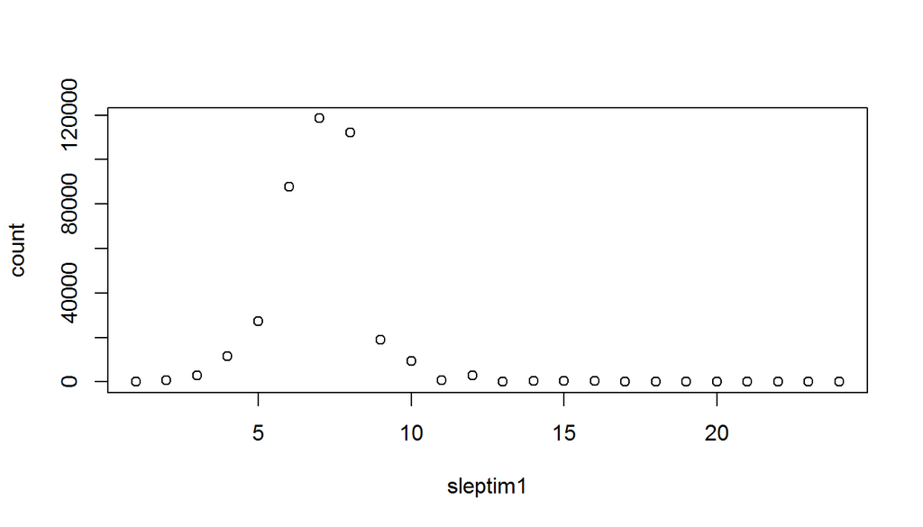

```r
plot(df %>% group_by(sleptim1) %>% summarise(count = n()))
```

We are going to consider population who slept above or equal to 7 hours as “Had Sufficient Sleep” and below “Not Had Sufficient Sleep”.  
**Ref:** https://www.health.harvard.edu/staying-healthy/how-much-sleep-do-we-really-need

```r
df <- df %>% mutate(sufsleep = df$sleptim1 >= 7)
```

```r
prop.table(table(df$sufsleep)*100)
```

```
##
##     FALSE      TRUE
## 0.3300575 0.6699425
```

We are also going to segregate mental health status as reported by population into three levels based on the days had mental health issues.

```r
df <- df %>% mutate(menthlthlvl = if_else(df$menthlth<=10,"LVL 1",if_else(df$menthlth<=20,"LVL 2", "LVL 3")))
```

Now, let’s plot the distribution of population between sufficient sleep and mental health status levels.

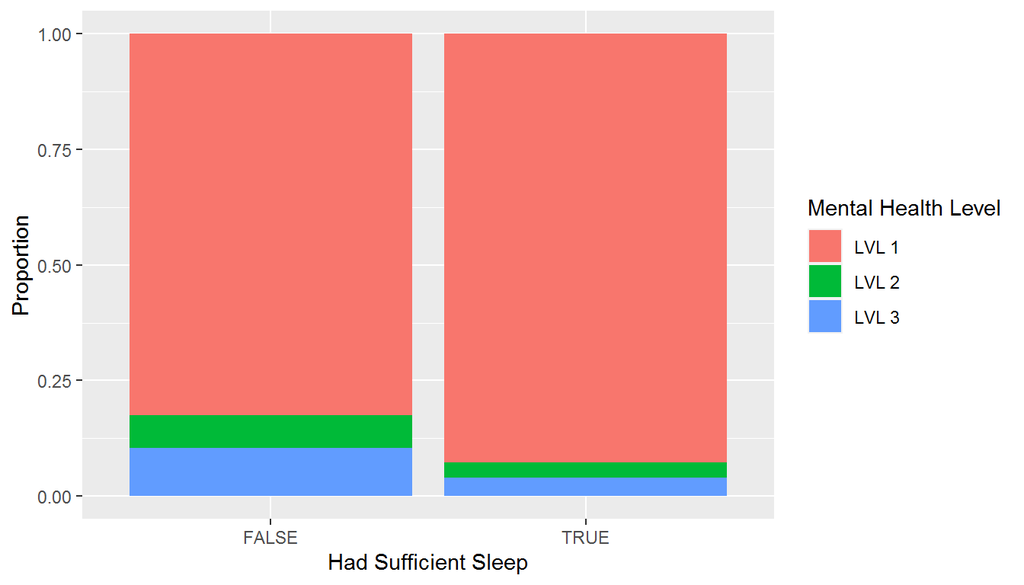

```r
ggplot(df) + aes(x=sufsleep, fill=menthlthlvl) + geom_bar(position = "fill") +
xlab("Had Sufficient Sleep") + ylab("Proportion") + scale_fill_discrete(name="Mental Health Level")
```

**Conclusion**  
- From the distribution it appears that people who had sufficient sleep dealt with lesser duration from mental health issues.

**Research Question 2 Analysis**

Variables of our interest for RQ2:  
- sufsleep  
- menthlthlvl  
- X_incomg

Income distribution among population from the observational data is as below.

```r
totalObsCount <- nrow(df)
df %>% group_by(X_incomg) %>% summarise(percent = n()/totalObsCount*100)
```

```
## # A tibble: 5 x 2
##   X_incomg                     percent
##   <fct>                          <dbl>
## 1 Less than $15,000               11.9
## 2 $15,000 to less than $25,000    17.9
## 3 $25,000 to less than $35,000    11.6
## 4 $35,000 to less than $50,000    14.8
## 5 $50,000 or more                 43.9
```

Plotting the income distribution graph for better understanding of data spread.

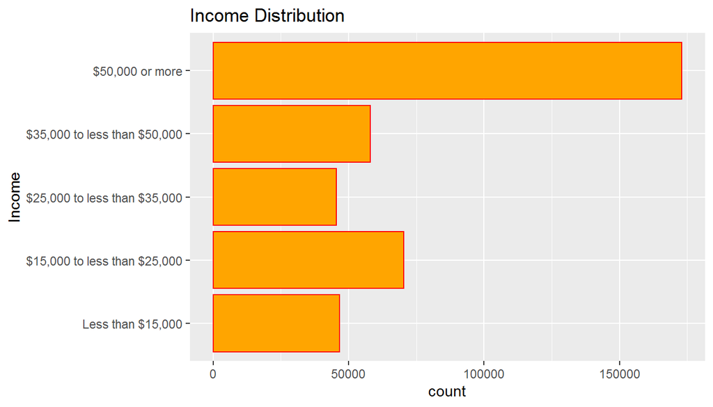

```r
ggplot(df, aes(x=X_incomg)) + geom_bar(color = "red", fill = "orange") + ggtitle('Income Distribution') + xlab('Income') + coord_flip()
```

Let’s add the income distribution to the plot of mental health levels and sufficient sleep to find any impact of income distribution.

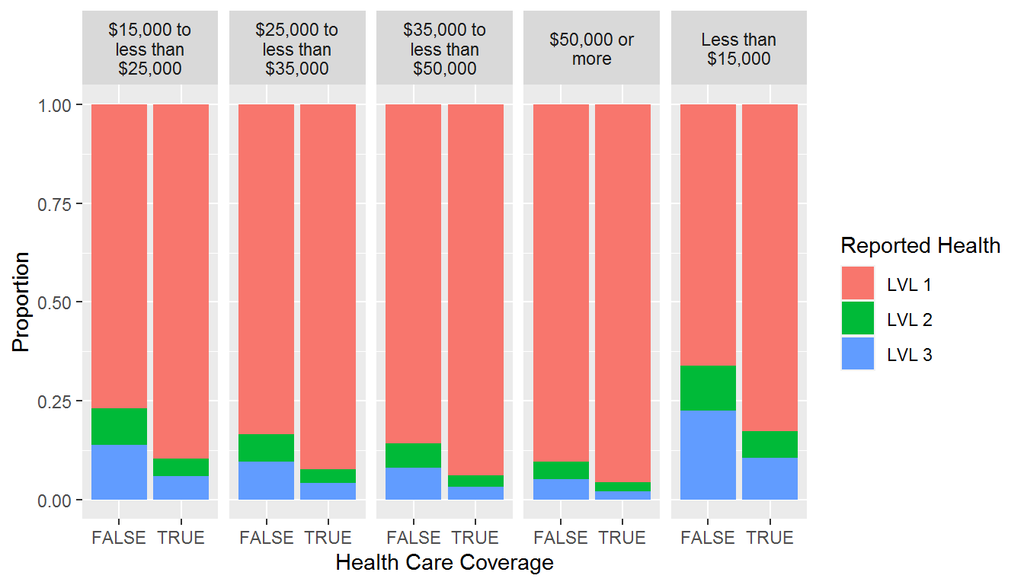

```r
df <- mutate(df, X_incomg_wrap = str_wrap(X_incomg, width = 14))
ggplot(df) + aes(x=sufsleep, fill=menthlthlvl) + geom_bar(position = "fill") + facet_grid(.~X_incomg_wrap) + xlab("Health Care Coverage") + ylab("Proportion") + scale_fill_discrete(name="Reported Health")
```

**Research Question 3 Analysis**

Variables of our interest for RQ3:  
- sleptim1  
- genhlth  
- X_bmi5cat

Let’s view the obesity distribution as a proportion among population.

```r
prop.table(table(df$X_bmi5cat)*100)
```

```
##
##   Underweight Normal weight    Overweight         Obese
##    0.01614218    0.32578761    0.36253997    0.29553023
```

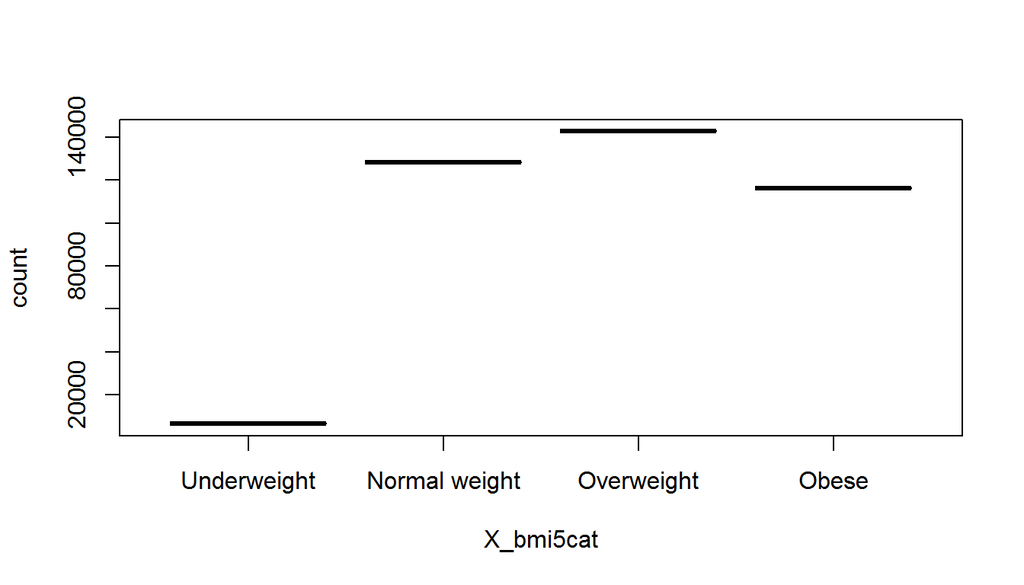

```r
plot(df %>% group_by(X_bmi5cat) %>% summarise(count = n()))
```

```r
prop.table(table(df$genhlth)*100)
```

```
##
## Excellent Very good      Good      Fair      Poor
## 0.1803403 0.3342892 0.3023757 0.1300773 0.0529174
```

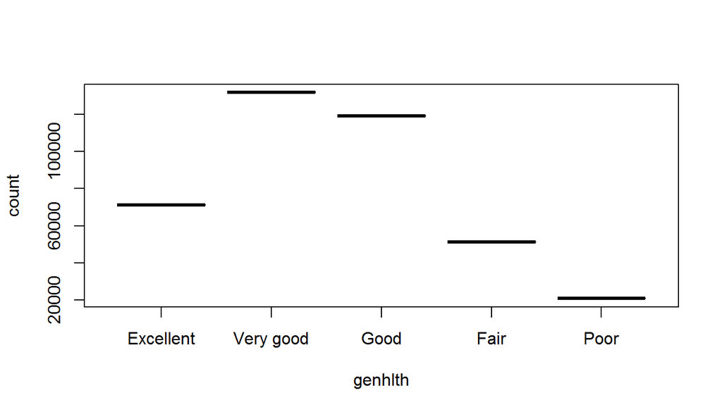

```r
plot(df %>% group_by(genhlth) %>% summarise(count = n()))
```

We are plotting the relation and impact of obesity levels and sleep time on general health among population.

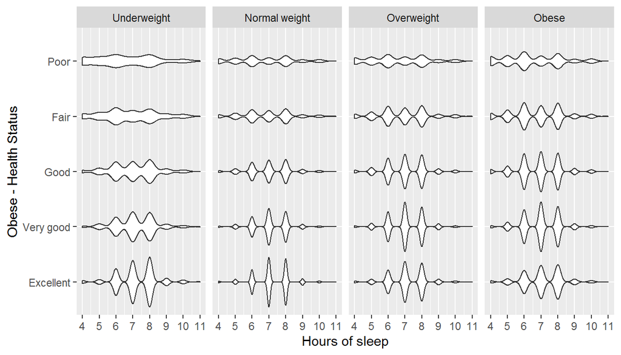

```r
ggplot(data = df , aes(x = genhlth, y = sleptim1)) +  geom_violin() + xlab("Obese - Health Status") + ylab ("Hours of sleep") + scale_y_continuous(limits = c(4, 11), breaks = c(4:11)) +  coord_flip() + facet_grid(.~X_bmi5cat)
```